# Part I - (Loan Dataset Prosper)

## by (Mgbekwute Jecinta Obianuju)

## Introduction

This data set contains 113,937 loans with 81 variables on each loan, including loan amount, borrower rate, current loan status and borrower income etc.

```python
# import all packages and set plots to be embedded inline
import numpy as np
import pandas as pd
import matplotlib.pyplot as plt
import seaborn as sb

%matplotlib inline
```

> Load in your dataset and describe its properties through the questions below. Try and motivate your exploration goals through this section.

```python
# load in the dataset into a pandas dataframe,print statistics
prosperloan=pd.read_csv('prosperLoanData.csv')
```

```python
# high-level overview of data shape
prosperloan.shape
```

```
(113937, 81)
```

```python
# high-level overview of composition
prosperloan.info()
```

```
<class 'pandas.core.frame.DataFrame'>
RangeIndex: 113937 entries, 0 to 113936
Data columns (total 81 columns):
 #   Column                               Non-Null Count   Dtype
---  ------                               --------------   -----
 0   ListingKey                           113937 non-null  object
 1   ListingNumber                        113937 non-null  int64
 2   ListingCreationDate                  113937 non-null  object
 3   CreditGrade                          28953 non-null   object
 4   Term                                 113937 non-null  int64
 5   LoanStatus                           113937 non-null  object
 6   ClosedDate                           55089 non-null   object
 7   BorrowerAPR                          113912 non-null  float64
 8   BorrowerRate                         113937 non-null  float64
 9   LenderYield                          113937 non-null  float64
```

[output cut: 73 more lines]

```python
# high-level overview of data sample
prosperloan.tail(15)
```

|  | ListingKey | ListingNumber | ListingCreationDate | CreditGrade | Term | LoanStatus | ClosedDate | BorrowerAPR | BorrowerRate | LenderYield | ... | LP_ServiceFees | LP_CollectionFees | LP_GrossPrincipalLoss | LP_NetPrincipalLoss | LP_NonPrincipalRecoverypayments | PercentFunded | Recommendations | InvestmentFromFriendsCount | InvestmentFromFriendsAmount | Investors |
| --- | --- | --- | --- | --- | --- | --- | --- | --- | --- | --- | --- | --- | --- | --- | --- | --- | --- | --- | --- | --- | --- |
| 113922 | D2293427338962159DA5143 | 379986 | 2008-08-08 16:58:54.760000000 | C | 36 | Completed | 2011-08-19 00:00:00 | 0.15094 | 0.1295 | 0.1195 | ... | -81.95 | 0.0 | 0.00 | 0.0 | 0.0 | 1.0 | 0 | 0 | 0.0 | 145 |
| 113923 | E334343080922352965DF86 | 395877 | 2008-09-10 08:26:30.537000000 | B | 36 | Completed | 2011-09-23 00:00:00 | 0.22378 | 0.2089 | 0.1989 | ... | -135.50 | 0.0 | 0.00 | 0.0 | 0.0 | 1.0 | 0 | 0 | 0.0 | 270 |
| 113924 | E340356181565702714DBCE | 657862 | 2012-10-20 19:15:52.670000000 | NaN | 60 | Current | NaN | 0.17317 | 0.1499 | 0.1399 | ... | -60.83 | 0.0 | 0.00 | 0.0 | 0.0 | 1.0 | 1 | 0 | 0.0 | 83 |
| 113925 | E3423576946812123E4798D | 760946 | 2013-04-25 13:54:45.017000000 | NaN | 36 | Current | NaN | 0.31032 | 0.2712 | 0.2612 | ... | -27.92 | 0.0 | 0.00 | 0.0 | 0.0 | 1.0 | 0 | 0 | 0.0 | 1 |
| 113926 | E34333654295683286C35C2 | 28121 | 2006-08-01 10:31:31.143000000 | E | 36 | Defaulted | 2007-09-06 00:00:00 | 0.29776 | 0.2900 | 0.2850 | ... | -9.34 | 0.0 | 2536.11 | 2536.1 | 0.0 | 1.0 | 0 | 0 | 0.0 | 39 |
| 113927 | E3433419834735803891976 | 322787 | 2008-04-30 21:25:19.670000000 | AA | 36 | Completed | 2011-05-09 00:00:00 | 0.07469 | 0.0679 | 0.0579 | ... | -68.47 | 0.0 | 0.00 | 0.0 | 0.0 | 1.0 | 2 | 0 | 0.0 | 194 |
| 113928 | E34935176664905343E01EA | 510097 | 2011-06-06 19:02:44.443000000 | NaN | 36 | Completed | 2011-09-19 00:00:00 | 0.22362 | 0.1899 | 0.1799 | ... | -4.41 | 0.0 | 0.00 | 0.0 | 0.0 | 1.0 | 0 | 0 | 0.0 | 25 |
| 113929 | E3553583161337791FCB87F | 830413 | 2013-07-06 17:40:01.657000000 | NaN | 36 | Completed | 2014-02-07 00:00:00 | 0.30285 | 0.2639 | 0.2539 | ... | -6.54 | 0.0 | 0.00 | 0.0 | 0.0 | 1.0 | 0 | 0 | 0.0 | 26 |
| 113930 | E35D3584034795373BCD69A | 831523 | 2013-07-08 10:24:49.700000000 | NaN | 36 | Current | NaN | 0.20053 | 0.1639 | 0.1539 | ... | -16.51 | 0.0 | 0.00 | 0.0 | 0.0 | 1.0 | 0 | 0 | 0.0 | 52 |
| 113931 | E36F36005339663245C20F8 | 1141292 | 2014-01-16 20:13:08.040000000 | NaN | 60 | Current | NaN | 0.15016 | 0.1274 | 0.1174 | ... | -21.23 | 0.0 | 0.00 | 0.0 | 0.0 | 1.0 | 0 | 0 | 0.0 | 1 |
| 113932 | E6D9357655724827169606C | 753087 | 2013-04-14 05:55:02.663000000 | NaN | 36 | Current | NaN | 0.22354 | 0.1864 | 0.1764 | ... | -75.58 | 0.0 | 0.00 | 0.0 | 0.0 | 1.0 | 0 | 0 | 0.0 | 1 |
| 113933 | E6DB353036033497292EE43 | 537216 | 2011-11-03 20:42:55.333000000 | NaN | 36 | FinalPaymentInProgress | NaN | 0.13220 | 0.1110 | 0.1010 | ... | -30.05 | 0.0 | 0.00 | 0.0 | 0.0 | 1.0 | 0 | 0 | 0.0 | 22 |
| 113934 | E6E13596170052029692BB1 | 1069178 | 2013-12-13 05:49:12.703000000 | NaN | 60 | Current | NaN | 0.23984 | 0.2150 | 0.2050 | ... | -16.91 | 0.0 | 0.00 | 0.0 | 0.0 | 1.0 | 0 | 0 | 0.0 | 119 |
| 113935 | E6EB3531504622671970D9E | 539056 | 2011-11-14 13:18:26.597000000 | NaN | 60 | Completed | 2013-08-13 00:00:00 | 0.28408 | 0.2605 | 0.2505 | ... | -235.05 | 0.0 | 0.00 | 0.0 | 0.0 | 1.0 | 0 | 0 | 0.0 | 274 |
| 113936 | E6ED3600409833199F711B7 | 1140093 | 2014-01-15 09:27:37.657000000 | NaN | 36 | Current | NaN | 0.13189 | 0.1039 | 0.0939 | ... | -1.70 | 0.0 | 0.00 | 0.0 | 0.0 | 1.0 | 0 | 0 | 0.0 | 1 |

15 rows × 81 columns

```python
# convert ProsperRating into ordered categorical types
ordinal_var_dict ={'ProsperRating (Alpha)': ['N/A','HR','E','D','C','B','A','AA']}
for var in ordinal_var_dict:
    ordered_var = pd.api.types.CategoricalDtype(ordered = True, categories = ordinal_var_dict[var])
    prosperloan[var] = prosperloan[var].astype(ordered_var)
```

```python
# descriptive statistics for numerical variables
prosperloan.describe()
```

|  | ListingNumber | Term | BorrowerAPR | BorrowerRate | LenderYield | EstimatedEffectiveYield | EstimatedLoss | EstimatedReturn | ProsperRating (numeric) | ProsperScore | ... | LP_ServiceFees | LP_CollectionFees | LP_GrossPrincipalLoss | LP_NetPrincipalLoss | LP_NonPrincipalRecoverypayments | PercentFunded | Recommendations | InvestmentFromFriendsCount | InvestmentFromFriendsAmount | Investors |
| --- | --- | --- | --- | --- | --- | --- | --- | --- | --- | --- | --- | --- | --- | --- | --- | --- | --- | --- | --- | --- | --- |
| count | 1.139370e+05 | 113937.000000 | 113912.000000 | 113937.000000 | 113937.000000 | 84853.000000 | 84853.000000 | 84853.000000 | 84853.000000 | 84853.000000 | ... | 113937.000000 | 113937.000000 | 113937.000000 | 113937.000000 | 113937.000000 | 113937.000000 | 113937.000000 | 113937.000000 | 113937.000000 | 113937.000000 |
| mean | 6.278857e+05 | 40.830248 | 0.218828 | 0.192764 | 0.182701 | 0.168661 | 0.080306 | 0.096068 | 4.072243 | 5.950067 | ... | -54.725641 | -14.242698 | 700.446342 | 681.420499 | 25.142686 | 0.998584 | 0.048027 | 0.023460 | 16.550751 | 80.475228 |
| std | 3.280762e+05 | 10.436212 | 0.080364 | 0.074818 | 0.074516 | 0.068467 | 0.046764 | 0.030403 | 1.673227 | 2.376501 | ... | 60.675425 | 109.232758 | 2388.513831 | 2357.167068 | 275.657937 | 0.017919 | 0.332353 | 0.232412 | 294.545422 | 103.239020 |
| min | 4.000000e+00 | 12.000000 | 0.006530 | 0.000000 | -0.010000 | -0.182700 | 0.004900 | -0.182700 | 1.000000 | 1.000000 | ... | -664.870000 | -9274.750000 | -94.200000 | -954.550000 | 0.000000 | 0.700000 | 0.000000 | 0.000000 | 0.000000 | 1.000000 |
| 25% | 4.009190e+05 | 36.000000 | 0.156290 | 0.134000 | 0.124200 | 0.115670 | 0.042400 | 0.074080 | 3.000000 | 4.000000 | ... | -73.180000 | 0.000000 | 0.000000 | 0.000000 | 0.000000 | 1.000000 | 0.000000 | 0.000000 | 0.000000 | 2.000000 |
| 50% | 6.005540e+05 | 36.000000 | 0.209760 | 0.184000 | 0.173000 | 0.161500 | 0.072400 | 0.091700 | 4.000000 | 6.000000 | ... | -34.440000 | 0.000000 | 0.000000 | 0.000000 | 0.000000 | 1.000000 | 0.000000 | 0.000000 | 0.000000 | 44.000000 |
| 75% | 8.926340e+05 | 36.000000 | 0.283810 | 0.250000 | 0.240000 | 0.224300 | 0.112000 | 0.116600 | 5.000000 | 8.000000 | ... | -13.920000 | 0.000000 | 0.000000 | 0.000000 | 0.000000 | 1.000000 | 0.000000 | 0.000000 | 0.000000 | 115.000000 |
| max | 1.255725e+06 | 60.000000 | 0.512290 | 0.497500 | 0.492500 | 0.319900 | 0.366000 | 0.283700 | 7.000000 | 11.000000 | ... | 32.060000 | 0.000000 | 25000.000000 | 25000.000000 | 21117.900000 | 1.012500 | 39.000000 | 33.000000 | 25000.000000 | 1189.000000 |

8 rows × 61 columns

### What is/are the main feature(s) of interest in your dataset?

i will be analysing MonthlyLoanPayment,EmploymentStatuesDuration,BorrowersRate,ProsperRating(Alpha)and OnTimeProsperPayment

### What features in the dataset do you think will help support your investigation into your feature(s) of interest?

I believe using Term and BorrowerAPR I can ascertain the OnTimeProsperPayment.StatedMonthlyIncome alongside LoanOriginalAmount can also support the investigation

## Univariate Exploration

First i will be looking at the distribution of each of the features

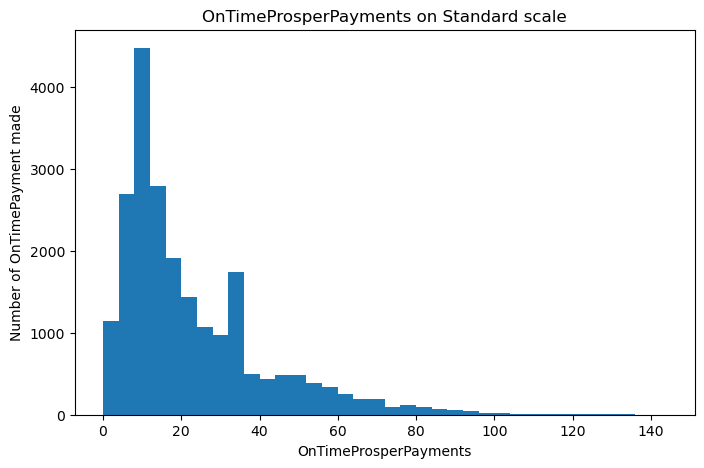

```python
# start with a standard-scaled plot of OnTimeProsperPayment
binsize = 4
bins = np.arange(0,prosperloan['OnTimeProsperPayments'].max()+binsize, binsize)
plt.figure(figsize=[8,5])
plt.hist(data = prosperloan, x = 'OnTimeProsperPayments', bins = bins)
plt.xlabel('OnTimeProsperPayments')
plt.ylabel('Number of OnTimePayment made')
plt.title('OnTimeProsperPayments on Standard scale');
```

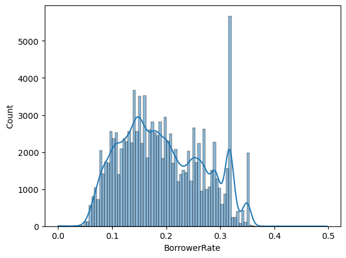

```python
#plot of BorrowerRate on Standard plot
sb.histplot(prosperloan['BorrowerRate'],kde=True);
```

From the graph it shows that there is an average borrower rate within 0.1 to 0.3

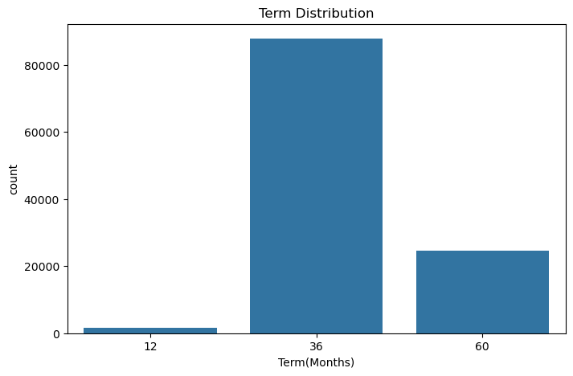

```python
# plot of Term(Duration of the Loan in Month)
ax = plt.figure(figsize =[8,5])

default_color = sb.color_palette()[0]
sb.countplot(data = prosperloan, x = 'Term', color = default_color)
plt.title('Term Distribution')
plt.xlabel('Term(Months)');
```

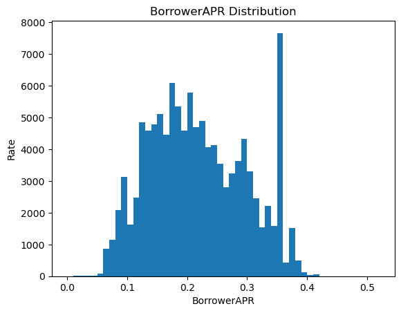

```python
# Plot of BorrowerAPR on Standard plot
bin_size = 0.01
bins = np.arange(0,prosperloan['BorrowerAPR'].max()+bin_size, bin_size)
plt.hist(prosperloan['BorrowerAPR'], bins = bins)
plt.xlabel('BorrowerAPR')
plt.ylabel('Rate')
plt.title('BorrowerAPR Distribution');
```

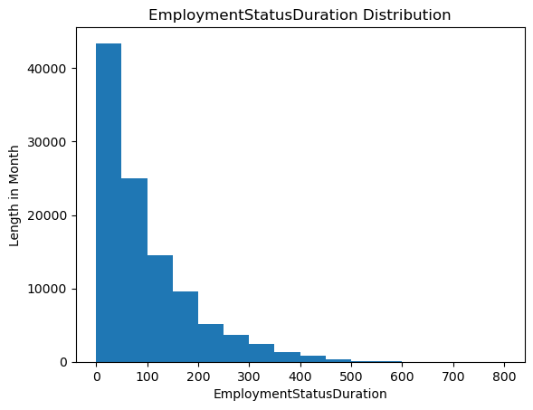

```python
# Plot of EmploymentStatusDuration on Standard plot
bins = np.arange(0, prosperloan['EmploymentStatusDuration'].max()+50 , 50)
plt.hist(prosperloan['EmploymentStatusDuration'], bins = bins)
plt.xlabel('EmploymentStatusDuration')
plt.ylabel('Length in Month')
plt.title('EmploymentStatusDuration Distribution');
```

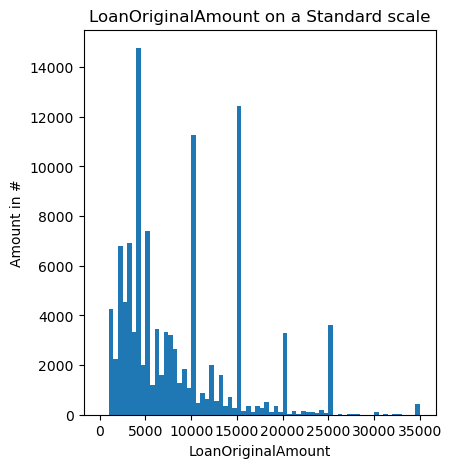

```python
# plotting LoanOriginalAmount on a standard scale
plt.figure(figsize = [10,5])
plt.subplot(1,2,1)
binsize = 500
bins = np.arange(0,prosperloan['LoanOriginalAmount'].max()+binsize, binsize)
plt.hist(data = prosperloan, x = 'LoanOriginalAmount',bins = bins);
plt.xlabel('LoanOriginalAmount')
plt.ylabel('Amount in #')
plt.title('LoanOriginalAmount on a Standard scale');
```

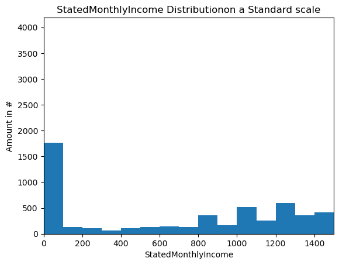

```python
# Plot of StatedMonthlyIncome on Standard plot
binsize = 100
bins = np.arange(0,prosperloan['StatedMonthlyIncome'].max()+binsize, binsize)
plt.xlim(0,1500)
plt.hist(data = prosperloan, x = 'StatedMonthlyIncome',bins = bins)
plt.xlabel('StatedMonthlyIncome')
plt.ylabel('Amount in #' )
plt.title('StatedMonthlyIncome Distributionon a Standard scale');
```

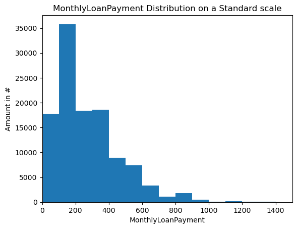

```python
# Plot of MonthlyLoanPayment on Standard plot
binsize = 100
bins = np.arange(0,prosperloan['MonthlyLoanPayment'].max()+binsize, binsize)
plt.xlim(0,1500)
plt.hist(data = prosperloan, x = 'MonthlyLoanPayment',bins = bins)
plt.xlabel('MonthlyLoanPayment')
plt.ylabel('Amount in #')
plt.title('MonthlyLoanPayment Distribution on a Standard scale')
```

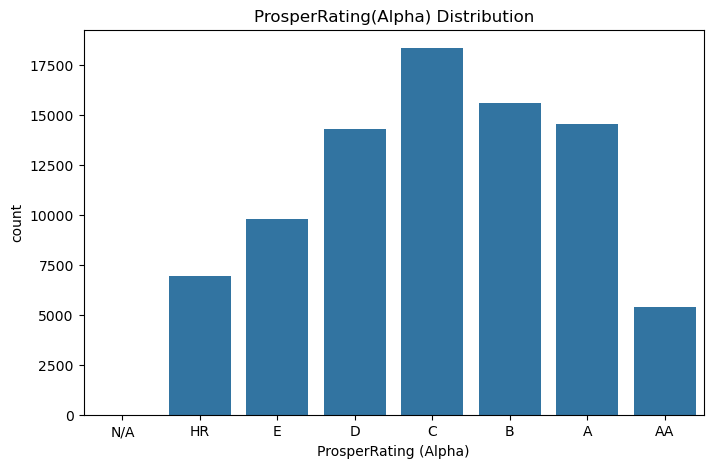

```python
# plot the ProsperRating(Alpha) ordinal variable's distribution.
ax = plt.figure(figsize =[8,5])

default_color = sb.color_palette()[0]
sb.countplot(data = prosperloan, x = 'ProsperRating (Alpha)', color = default_color)
plt.title('ProsperRating(Alpha) Distribution');
```

The ProsperRating(Alpha) showed the highest peak at 'C' followed by 'B', 'A' and 'D'

### Discuss the distribution(s) of your variable(s) of interest. Were there any unusual points? Did you need to perform any transformations

BorrowerRate,LoanOriginalAmount,MonthlyLoanPayment and EmploymentStatusDuration were plotted using standard plot for visualization purpose.

## Bivariate Exploration

> In this section, investigate relationships between pairs of variables in your data. Make sure the variables that you cover here have been introduced in some fashion in the previous section (univariate exploration).

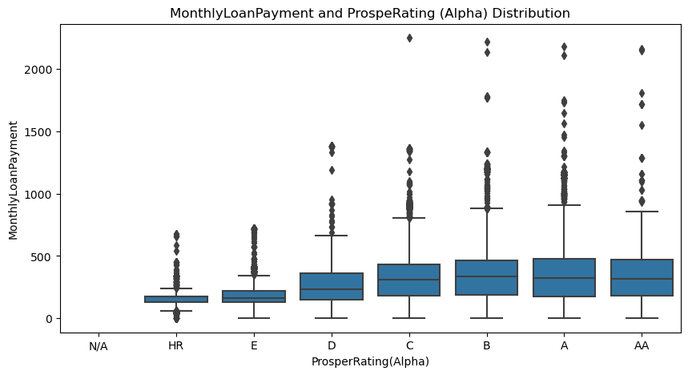

```python
# sample = np.random.choice(prosperloan.shape[0], 2000, replace = False)
# prosperloan_samp = prosperloan.loc[samples,:]

# def boxgrid(x,y, **kwargs):
#     """Quick hack for creating box plots with seaborn's PairGrid. """
#     default_color = sb.color_palette()[0]
#     sb.boxplot(x,y, color = default_color)

plt.figure(figsize = [10, 5])
sb.boxplot(data = prosperloan, y = 'MonthlyLoanPayment', x = 'ProsperRating (Alpha)', color = default_color)
plt.ylabel('MonthlyLoanPayment')
plt.xlabel('ProsperRating(Alpha)')
plt.title('MonthlyLoanPayment and ProspeRating (Alpha) Distribution')
plt.show();
```

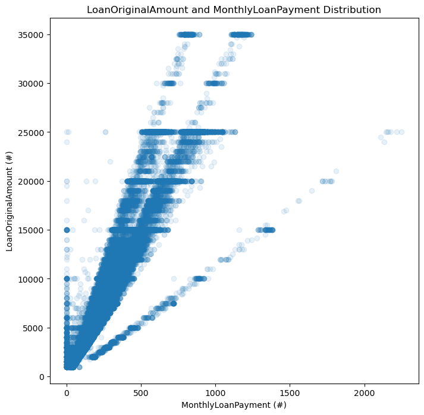

```python
#  A plot of LoanOriginalAmount and MonthlyLoanPayment
plt.figure(figsize = [8,8])
plt.scatter(data = prosperloan, x = 'MonthlyLoanPayment', y = 'LoanOriginalAmount', alpha = 1/10)
plt.xlabel('MonthlyLoanPayment (#)')
plt.ylabel('LoanOriginalAmount (#)')
plt.title('LoanOriginalAmount and MonthlyLoanPayment Distribution')
plt.show()
```

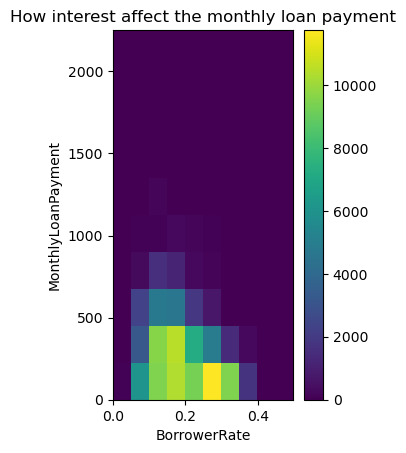

```python
plt.subplot(1,2,2)
plt.hist2d(data=prosperloan,x='BorrowerRate',y='MonthlyLoanPayment')
plt.colorbar()
plt.xlabel('BorrowerRate')
plt.ylabel('MonthlyLoanPayment')
plt.title('How interest affect the monthly loan payment');
```

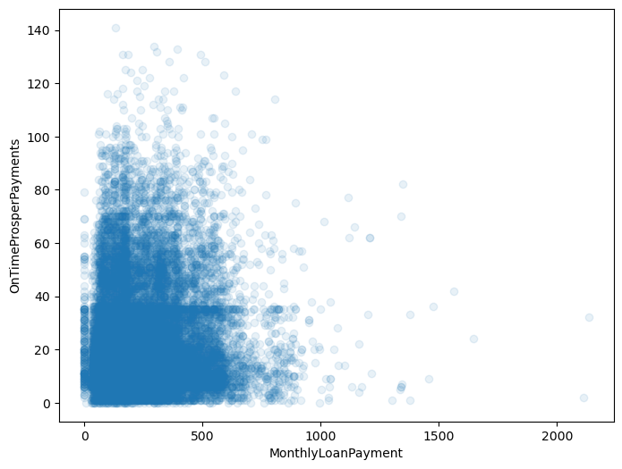

```python
plt.figure(figsize = [8,6])
plt.scatter(data = prosperloan, x = 'MonthlyLoanPayment', y = 'OnTimeProsperPayments', alpha = 1/10)
plt.xlabel('MonthlyLoanPayment')
plt.ylabel('OnTimeProsperPayments')
plt.show()
```

[figure not shown]

```python
plt.scatter(data = prosperloan, x = 'LoanOriginalAmount', y = 'MonthlyLoanPayment', c = 'ProsperScore', cmap = 'inferno_r')
plt.colorbar(label ='ProsperScore')
plt.xlabel('OnTimeProsperPayments')
plt.ylabel('MonthlyLoanPayment')
plt.title('MonthlyLoanPayment,OnTimeProsperPayments and ProsperScore');
```

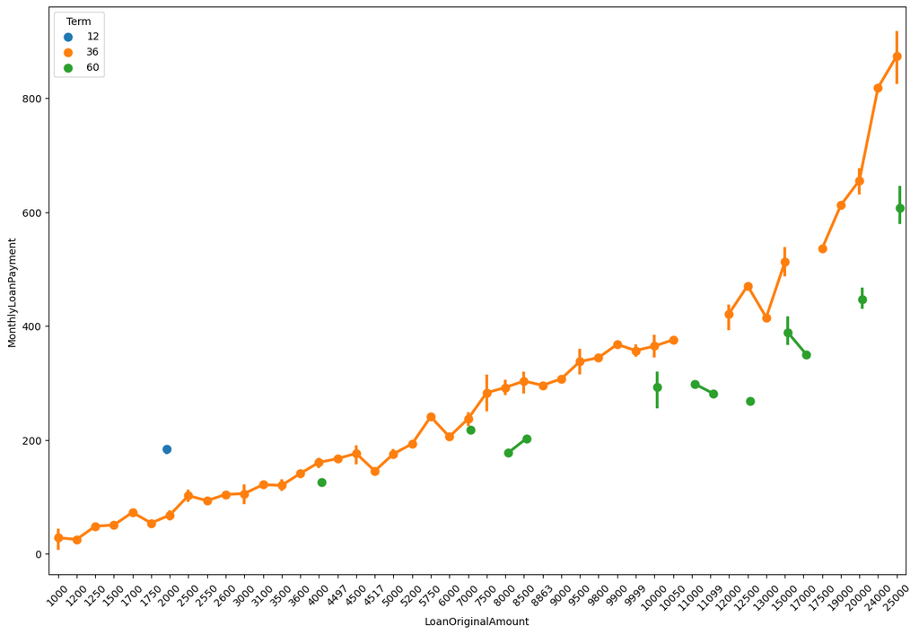

```python
plt.figure(figsize = [15,10])
samples = np.random.choice(prosperloan.shape[0], 150, replace = False)
prosper_samp = prosperloan.loc[samples,:]
ax = sb.pointplot(data = prosper_samp, y = 'MonthlyLoanPayment', x = 'LoanOriginalAmount', hue = 'Term', dodge = 0.3, linestyle = '')
plt.ylabel('MonthlyLoanPayment')
ax.set_yticklabels([],minor = True)
plt.xticks(rotation = 45)
plt.show();
```

From the distribution, most MonthlyLoanPayment were possible in 36 months irrespective of the LoanOriginalAmount.